# KAD Profiling

24 February 2020

KAD is valuable for evaluating the accuracy of nucleotide base quality of assemblies. Briefly, abundance of k-mers are quantified for both sequencing reads and assembly sequences. Comparison of both values results in a single value per k-mer, K-mer Abundance Difference (KAD), which indicates how well the assembly matches read data for each k-mer.

### Run environment and KAD script

**R environment**:  
x86_64-pc-linux-gnu, x86_64, linux-gnu, x86_64, linux-gnu, , 3, 5.2, 2018, 12, 20, 75870, R, R version 3.5.2 (2018-12-20), Eggshell Igloo

**KAD script**:  
KADprofile.pl 0.15

### INPUT

**1. reads**  
ID: reads

```
MG1655_1.fq.gz
MG1655_2.fq.gz
```

**2. assemblies**

```
U00096.1:   U00096.1.fasta
U00096.3:   U00096.3.fasta
```

### Parameters for k-mer analysis

1. jellyfish 2.3.0 was used to generate k-mers from sequences
2. length of k-mer: 25
3. minimum counts of k-mers: 5

### Analyis 1: read k-mer analysis

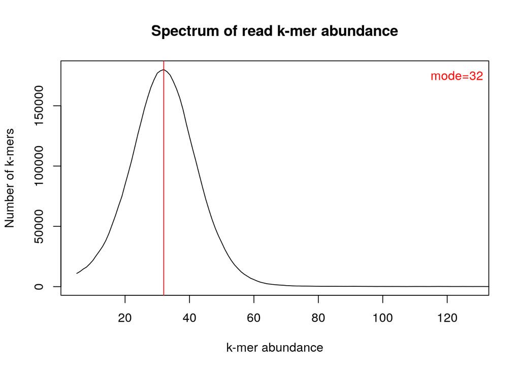

Fig 1. Spectrum of counts of read k-mers

From most genomes, single-copy k-mers each of which is present once in the genome are dominant among all non-redundant k-mers derived from the genome. The mode of sequencing depths of single-copy kmers, representing sequencing depth of read data, can be estimated from the spectrum of k-mer abundance from reads (Fig 1).

The mode of counts of read k-mers: 32. The mode is highlighted in red in Fig1.

### Analysis 2: KAD summary for each assembly

Table 1. Summary of KADs

[output not shown]

Here are criteria used to define k-mer categories:  
1. Good: k-mers basically containing no errors; KADs in [-0.5, 0.5]. Note that some k-mers with low counts from reads but absent in the assembly are in this category.  
2. Error: k-mers showing a single copy in the assembly but with no reads supported; KADs=-1.  
3. OverRep: k-mers showing multiple locations in the assembly but read depths indicate lower copies; KADs <= -0.8 and do not equal -1.  
4. LowUnderRep: k-mers with less copies in the assembly as compared to copies indicated by read depths; KADs in [0.75, 2].  
5. HighUnderRep: k-mers showing less copies at a high degree in the assembly as compared to copies indicated by read depths; KADs >=2.

Table 2. Estimation of base errors

| Data | BaseErrorNum_24 | BaseErrorNum_14 |
| --- | --- | --- |
| U00096.1 | 1363 | 2337 |
| U00096.3 | 1160 | 1989 |

Note: Of the header, “BaseErrorNum_xx” represents the number of base errors detected through dividing the number of error k-mers by the conversion rate of “xx”. Because the read depth is <40, the error estimation might be higher than actual errors.

### Analysis 3: KAD profiles

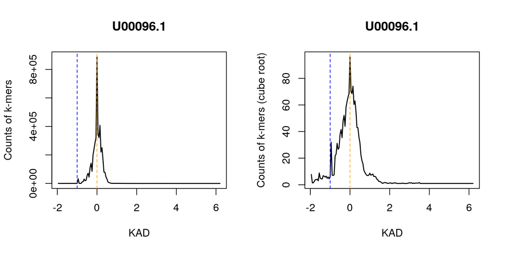

Fig 2. KAD profiles

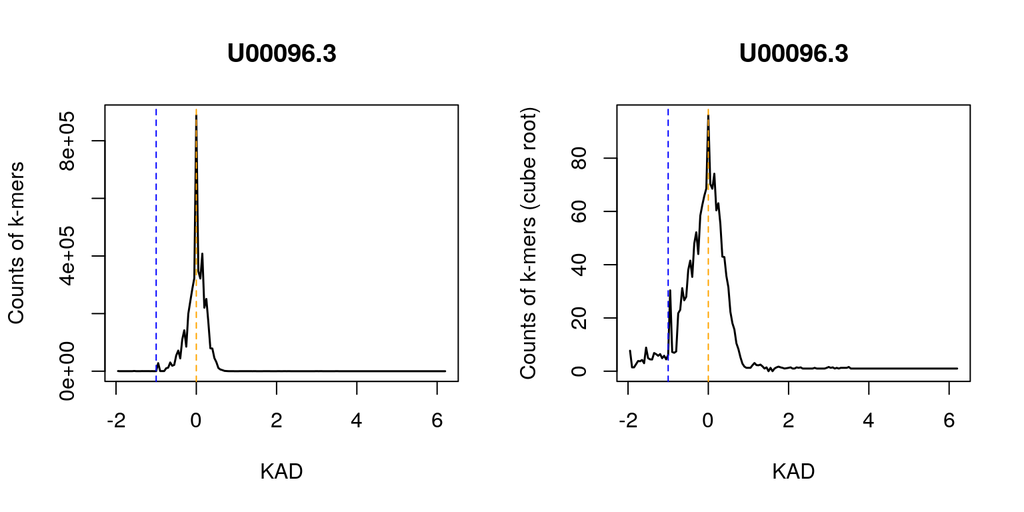

Fig 2. KAD profiles